# Image Processing 2 - Morphological Operations

### اماني عبدالحميد عبدالرحمن طه ابراهيم 1300308

### Email: amanyabdo1194@gmail.com

## Import Libraries

```python
import cv2
import numpy as np
from matplotlib import pyplot as plt
```

```python
def plot_side_by_side(image1, title1, image2, title2,x,y):
    fig, (img1, img2) = plt.subplots(1, 2, figsize=(x, y))
    img1.imshow(image1)
    img2.imshow(image2)
    img1.set_title(title1)
    img2.set_title(title2)
    #img1.axis("off")
    #img2.axis("off")
    plt.show()
```

Note: "SE" represents -> Structuring Element

## Question 1

```python
image1 = cv2.imread('Square-circle.png',1)
```

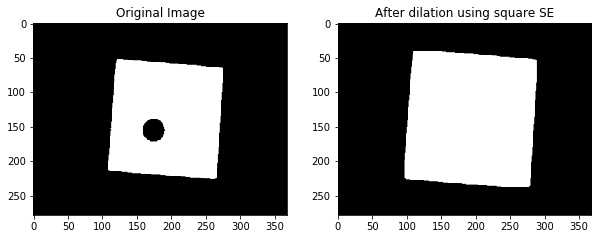

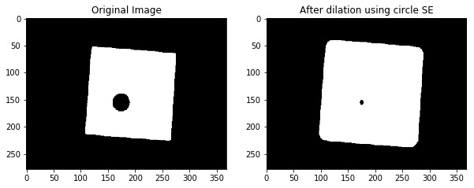

```python
image_dilated_sq = cv2.dilate(image1,cv2.getStructuringElement(cv2.MORPH_RECT,(25,25)),iterations = 1)
image_dilated_cir = cv2.dilate(image1,cv2.getStructuringElement(cv2.MORPH_ELLIPSE,(25,25)),iterations = 1)

plot_side_by_side(image1,"Original Image",image_dilated_sq,"After dilation using square SE",10,10 )
plot_side_by_side(image1,"Original Image",image_dilated_cir,"After dilation using circle SE",10,10 )
```

Observations: When using square and circle kernels with same size, the black hole has totally disappeared in case square but in case circle it has not disappeared.

## Question 2

```python
image2 = cv2.imread('Cameraman.png',1)
```

[figure not shown]

```python
image_dilated = cv2.dilate(image2,cv2.getStructuringElement(cv2.MORPH_ELLIPSE,(3,3)),iterations = 1)
plot_side_by_side(image2,"Original Image",image_dilated,"After pepper noise reduction",20,20 )
```

Note : the pepper noise only has disappeared after using dilation but salted noise still exists.

## Question 3

```python
image3 = cv2.imread('lady.png',1)
```

[figure not shown]

[figure not shown]

```python
dilated = cv2.dilate(image3,cv2.getStructuringElement(cv2.MORPH_RECT,(3,3)),iterations = 1)

edges = cv2.Canny(image3,100,200)
fig, (img1, img2) = plt.subplots(1, 2, figsize=(10, 10))
img1.imshow(image3)
plt.imshow(edges,"gray")
img1.set_title("Original Image")
img2.set_title("Edge Detection using Canny before dilation")
plt.show()

edges = cv2.Canny(dilated,100,200)
fig, (img1, img2) = plt.subplots(1, 2, figsize=(10, 10))
img1.imshow(dilated)
plt.imshow(edges,"gray")
img1.set_title("Dilated Image")
img2.set_title("Edge Detection using Canny after dilation")
plt.show()
```

Note: When we used canny for original image and made edge detection ,the edges were not clear enough, but after dilation, the edges became more clear and presice.

## Question 4

```python
image4 = cv2.imread('Circle.png',1)
```

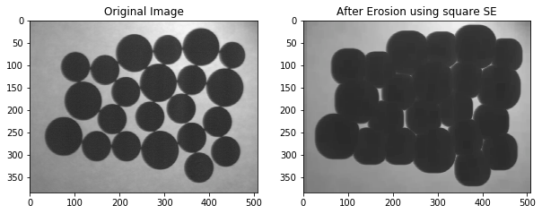

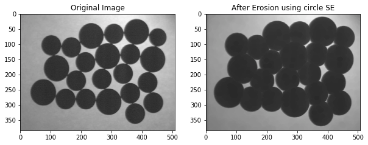

```python
erosion_sq = cv2.erode(image4,cv2.getStructuringElement(cv2.MORPH_RECT,(17,17)),iterations = 1)
plot_side_by_side(image4,"Original Image",erosion_sq,"After Erosion using square SE" ,10,10)

erosion_cir = cv2.erode(image4,cv2.getStructuringElement(cv2.MORPH_ELLIPSE,(17,17)),iterations = 1)
plot_side_by_side(image4,"Original Image",erosion_cir,"After Erosion using circle SE",10,10 )
```

Note: when we used circle kernel the black balls kept their shape as circles, but when we used square kernel the black balls changed their shape to be closer to squares not circles.

## Question 5

```python
image5 = cv2.imread('Circle.png',1)
#image5 = cv2.cvtColor(image5, cv2.COLOR_BGR2RGB)
```

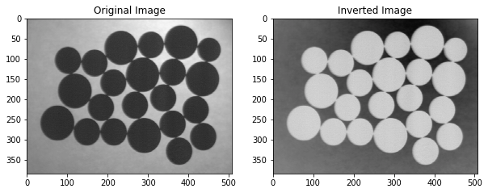

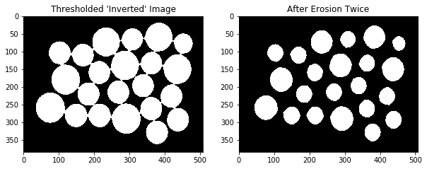

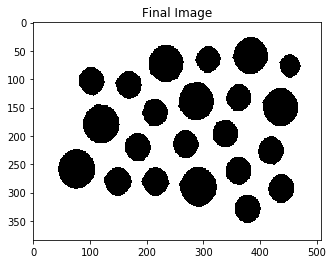

```python
inverted1 = 255 - image5
plot_side_by_side(image5,"Original Image",inverted1,"Inverted Image",10,10 )

retval,thresholded = cv2.threshold(inverted1,175,255,cv2.THRESH_BINARY)
erosion_ = cv2.erode(thresholded,cv2.getStructuringElement(cv2.MORPH_ELLIPSE,(9,9)),iterations = 2)
plot_side_by_side(thresholded,"Thresholded 'Inverted' Image",erosion_,"After Erosion Twice",10,10 )

inverted_back = 255 - erosion_
plt.imshow(inverted_back)
plt.title("Final Image")
plt.show()
```

Here we could to separate the balls from each other using thresholding and erosion.

## Question 6

```python
image6 = cv2.imread('Cameraman.png',1)
```

[figure not shown]

```python
image_eroded = cv2.erode(image6,cv2.getStructuringElement(cv2.MORPH_ELLIPSE,(3,3)),iterations = 1)
plot_side_by_side(image6,"Original Image",image_eroded,"After salted noise reduction",20,20 )
```

Here we could reduce salted noise using erosion but pepper noise still exists. To get image without noise we can use dilation and erosion.

## Question 7

```python
image7 = cv2.imread('Circle_and_Lines.png',1)
```

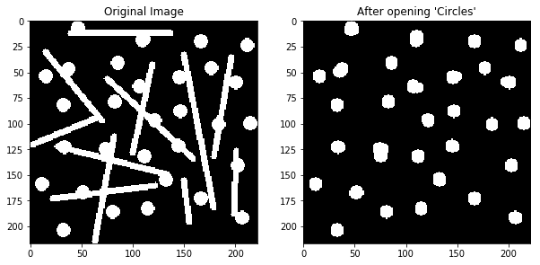

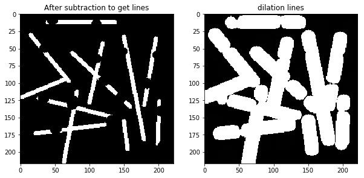

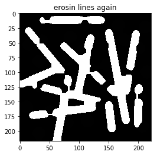

```python
opened = cv2.morphologyEx(image7, cv2.MORPH_OPEN, cv2.getStructuringElement(cv2.MORPH_ELLIPSE,(11,11)))
plot_side_by_side(image7,"Original Image",opened,"After opening 'Circles'",10,10 )

dilation_cir = cv2.dilate(opened,cv2.getStructuringElement(cv2.MORPH_ELLIPSE,(3,3)))

subtract = image7-dilation_cir
dilation_lin = cv2.dilate(subtract,cv2.getStructuringElement(cv2.MORPH_ELLIPSE,(15,15)))
plot_side_by_side(subtract,"After subtraction to get lines",dilation_lin,"dilation lines",10,10 )
erosion_lin = cv2.erode(dilation_lin,cv2.getStructuringElement(cv2.MORPH_RECT,(3,3)),iterations = 3)
plt.imshow(erosion_lin)
plt.title("erosin lines again")
plt.show()
```

```python
#algorithm to count circles
can = cv2.Canny(opened,100,200)
im2, circle_contours, hierarchy  = cv2.findContours(can.copy(),cv2.RETR_EXTERNAL, cv2.CHAIN_APPROX_SIMPLE)
print ("Circles Count: " ,len(circle_contours))
```

```
Circles Count:  30
```

I could not count lines unfortunately.

## Question 8

```python
image8 = cv2.imread('Dog.png',1)
```

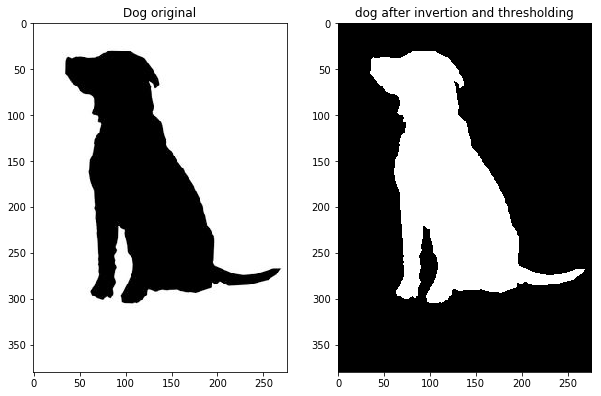

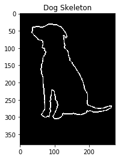

```python
inverted1 = 255 - image8
retval,thresholded = cv2.threshold(inverted1,175,255,cv2.THRESH_BINARY)
plot_side_by_side(image8,"Dog original",thresholded,"dog after invertion and thresholding",10,10 )

closed = cv2.erode(thresholded,cv2.getStructuringElement(cv2.MORPH_CROSS,(3,3)),iterations = 1)
skeleton = thresholded - closed
dilated_dog= cv2.dilate(skeleton,cv2.getStructuringElement(cv2.MORPH_CROSS,(3,3)),iterations = 1)
plt.imshow(dilated_dog)
plt.title("Dog Skeleton")
plt.show()
```

```python
#Dog skeleton area
can = cv2.Canny(dilated_dog,100,200)
im2, contours, hierarchy  = cv2.findContours(can.copy(),cv2.RETR_EXTERNAL, cv2.CHAIN_APPROX_SIMPLE)
print ("Dog Area: ",cv2.contourArea(contours[0]))
```

```
Dog Area:  31.5
```

```python
image8 = cv2.imread('Girl.png',1)
```

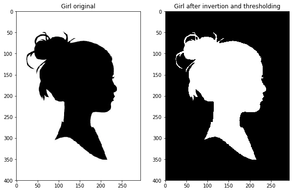

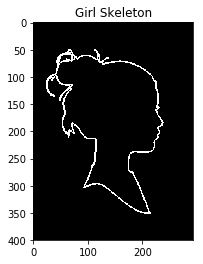

```python
inverted1 = 255 - image8
retval,thresholded = cv2.threshold(inverted1,175,255,cv2.THRESH_BINARY)
plot_side_by_side(image8,"Girl original",thresholded,"Girl after invertion and thresholding",10,10 )

closed = cv2.erode(thresholded,cv2.getStructuringElement(cv2.MORPH_CROSS,(3,3)),iterations = 1)
skeleton = thresholded - closed
dilated_girl= cv2.dilate(skeleton,cv2.getStructuringElement(cv2.MORPH_CROSS,(3,3)),iterations = 1)
plt.imshow(dilated_girl)
plt.title("Girl Skeleton")
plt.show()
```

```python
#Girl skeleton area
can = cv2.Canny(dilated_girl,100,200)
im2, contours, hierarchy  = cv2.findContours(can.copy(),cv2.RETR_EXTERNAL, cv2.CHAIN_APPROX_SIMPLE)
print ("Girl Area: ",cv2.contourArea(contours[0]))
```

```
Girl Area:  2.5
```

I could not get the center of mass unfortunately.

## Question 9

```python
kernel = np.array(([0,1,0],[1,-1,1],[0,1,0]),dtype="int")
HitandMiss = cv2.morphologyEx(image8, cv2.MORPH_HITMISS, kernel)
```

```
---------------------------------------------------------------------------
error                                     Traceback (most recent call last)
<ipython-input-24-e46185024745> in <module>()
      1 kernel = np.array(([0,1,0],[1,-1,1],[0,1,0]),dtype="int")
----> 2 HitandMiss = cv2.morphologyEx(image8, cv2.MORPH_HITMISS, kernel)

error: C:\bld\opencv_1519037241778\work\opencv-3.3.0\modules\imgproc\src\morph.cpp:2051: error: (-215) src.type() == CV_8UC1 in function cv::morphologyEx
```

I could not handle the error here.

## Question 10

# The End

```
                                          Thank You
```